# Relatório Atividade Prática 1

Grupo 5

18/12/2020

#### Integrantes do Grupo:

- Bruno Marcelino
- Daniel Rocha
- David Alexsander
- Felipe Robadel
- Gabriela Lamas

# Introdução e Tratamento dos Dados

Usaremos o conjunto de pacotes `"tidyverse"` para realizar algumas operações, sobretudo utilizando recursos gráficos.

```r
#Tratamento dos Dados

n_alunos <- c(23,19,30,22,23,29,35,36,33,25)

pont_med <- c(430,430,333,410,390,377,325,310,328,375)

library("tidyverse")
df <- tibble("Num_de_Alunos" = c(23,19,30,22,23,29,35,36,33,25),
                "Pont_Media" = c(430,430,333,410,390,377,325,310,328,375),
                )
```

# Respostas

#### QUESTÃO 1:

Criação de um gráfico de dispersão que relaciona os dois vetores previamente declarados.

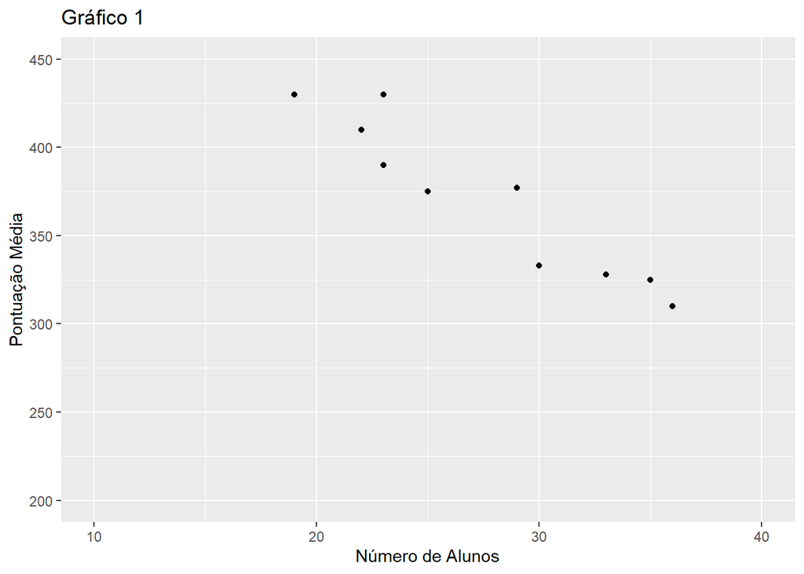

```r
grafico_1 <- ggplot(df, aes(x = Num_de_Alunos , y = Pont_Media)) +
 geom_point() +
 ggtitle("Gráfico 1") +
 xlab("Número de Alunos") +
 ylab("Pontuação Média") +
 xlim(10, 40) +
 ylim(200, 450)

print(grafico_1)
```

#### QUESTÃO 2:

Cálculo da média, variância e desvio-padrão da pontuação média dos alunos.

```r
media <- df$Pont_Media %>% mean
print(paste("A média das pontuações é de", media, "pontos"))
```

```
## [1] "A média das pontuações é de 370.8 pontos"
```

```r
variancia <- df$Pont_Media %>% var
print(paste("A variância das pontuações é de", variancia, "pontos"))
```

```
## [1] "A variância das pontuações é de 2002.84444444444 pontos"
```

```r
desvio_p <- df$Pont_Media %>% sd
print(paste("O desvio-padrão das pontuações é de", desvio_p, "pontos"))
```

```
## [1] "O desvio-padrão das pontuações é de 44.753150106383 pontos"
```

#### QUESTÃO 3:

Cálculo da correlação e covariância entre o número de alunos por turma e sua pontuação média.

```r
cova <- cov(df$Num_de_Alunos, df$Pont_Media)
print(paste("A covariância entre o número de alunos por turma e sua pontuação média é de", cova))
```

```
## [1] "A covariância entre o número de alunos por turma e sua pontuação média é de -251.444444444444"
```

```r
corr <- cor(df$Num_de_Alunos, df$Pont_Media)
print(paste("A correlação entre o número de alunos por turma e sua pontuação média é de", corr))
```

```
## [1] "A correlação entre o número de alunos por turma e sua pontuação média é de -0.947442434033449"
```

#### QUESTÃO 4:

Atribuição de uma regressão linear que tenha o número de alunos da turma como variável explicativa de sua pontuação média.

```r
reg <- lm(df$Pont_Media ~ df$Num_de_Alunos)
summary(reg)
```

```
##
## Call:
## lm(formula = df$Pont_Media ~ df$Num_de_Alunos)
##
## Residuals:
##      Min       1Q   Median       3Q      Max
## -19.9248 -10.6002  -0.8506   5.8631  27.0246
##
## Coefficients:
##                  Estimate Std. Error t value Pr(>|t|)
## (Intercept)      567.4272    23.9606  23.682 1.08e-08 ***
## df$Num_de_Alunos  -7.1501     0.8536  -8.376 3.13e-05 ***
## ---
## Signif. codes:  0 '***' 0.001 '**' 0.01 '*' 0.05 '.' 0.1 ' ' 1
##
## Residual standard error: 15.19 on 8 degrees of freedom
## Multiple R-squared:  0.8976, Adjusted R-squared:  0.8849
## F-statistic: 70.16 on 1 and 8 DF,  p-value: 3.132e-05
```

#### QUESTÃO 5:

Criação de um segundo gráfico, que contenha a reta de regressão estipulada no modelo acima.

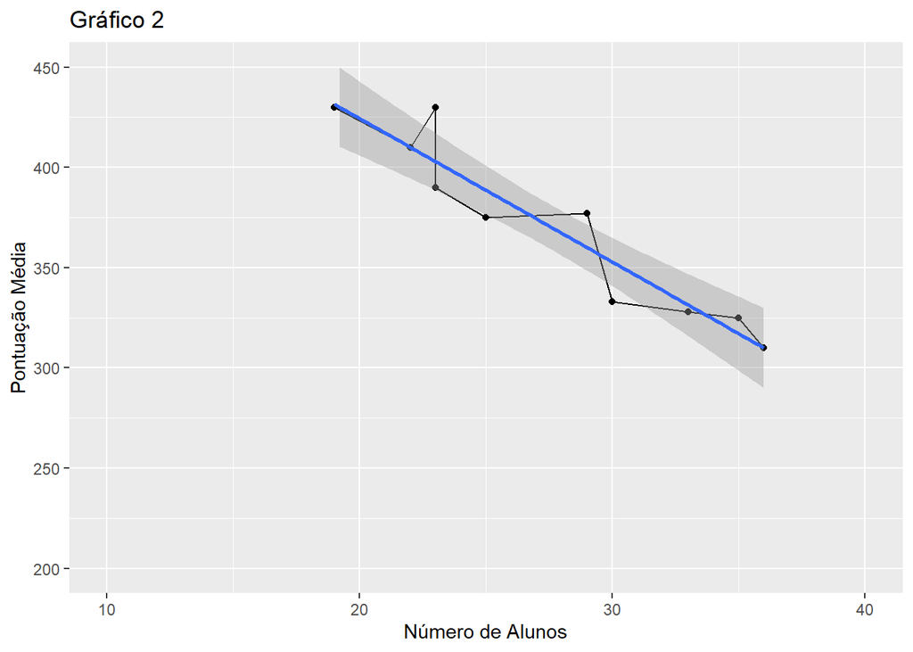

```r
grafico_2 <- ggplot(df, aes(x = Num_de_Alunos , y = Pont_Media)) +
        geom_point() +
        ggtitle("Gráfico 2") +
        geom_line() +
        xlab("Número de Alunos") +
        ylab("Pontuação Média") +
        xlim(10, 40) +
        ylim(200, 450) +
        geom_smooth(method = "lm")

print(grafico_2)
```

#### QUESTÃO 6:

Trazer o dado do r-quadrado da regressão.

```r
r_quadrado <- summary(reg)$r.squared
print(paste("O R-quadrado é igual a", round(r_quadrado, 2)))
```

```
## [1] "O R-quadrado é igual a 0.9"
```

#### QUESTÃO 7:

Criação de uma tabela com os coeficientes estimados (intercepto e coeficiente angular), erros padrão, estatísticas t, e p-valores da variável explicativa e do intercepto do modelo.

```r
estatisticas_da_reg <- summary(reg)
coef_estimados <- tibble("Coeficientes" = c("Intercepto", "Var.Explicativa"),
                         "Valor dos Coef" = estatisticas_da_reg$coefficients[c(1:2)],
                         "R-quadrado" = estatisticas_da_reg$r.squared,
                         "Erro-padrão" = estatisticas_da_reg$coefficients[c(3:4)],
                         "Estatística-t" = estatisticas_da_reg$coefficients[c(5:6)],
                         "P-Valor" = estatisticas_da_reg$coefficients[c(7:8)],
                         )

print(coef_estimados)
```

```
## # A tibble: 2 x 6
##   Coeficientes `Valor dos Coef` `R-quadrado` `Erro-padrão` `Estatística-t`
##   <chr>                   <dbl>        <dbl>         <dbl>           <dbl>
## 1 Intercepto             567.          0.898        24.0             23.7
## 2 Var.Explica~            -7.15        0.898         0.854           -8.38
## # ... with 1 more variable: `P-Valor` <dbl>
```

#### QUESTÃO 8:

Apresentar a matriz de variâncias e covariâncias dos coeficientes

```r
matriz_cov <- estatisticas_da_reg$cov.unscaled
 print(matriz_cov)
```

```
##                  (Intercept) df$Num_de_Alunos
## (Intercept)       2.48941548     -0.086887836
## df$Num_de_Alunos -0.08688784      0.003159558
```

#### QUESTÃO 9:

O erro-padrão é a medida de incerteza ao se estimar um parâmetro, e a estatística-t é a medida da distância entre a estimativa e uma distribuição com média zero. Quanto menor o erro-padrão, maior deverá ser o valor da estatística-t, o que reflete em um aumento do poder explicativo do nosso modelo.

As estatísticas da regressão fornecem o dado de que o p-valor do intercepto é **menor** do que 0.05. Isso significa que, por ser menor do que o valor do teste de significância (5%), a hipótese nula pode ser rejeitada e dizemos que o intercepto é **estatisticamente diferente** de zero.

A função `summary` também realiza o teste de significância a partir da seção `Signif. codes:`, que por ser avaliado em três asteriscos, reflete que a probablidade de não se rejeitar a hipótese nula é bem próxima de zero, estando de acordo com a conclusão obtida.

```r
summary(reg)
```

```
##
## Call:
## lm(formula = df$Pont_Media ~ df$Num_de_Alunos)
##
## Residuals:
##      Min       1Q   Median       3Q      Max
## -19.9248 -10.6002  -0.8506   5.8631  27.0246
##
## Coefficients:
##                  Estimate Std. Error t value Pr(>|t|)
## (Intercept)      567.4272    23.9606  23.682 1.08e-08 ***
## df$Num_de_Alunos  -7.1501     0.8536  -8.376 3.13e-05 ***
## ---
## Signif. codes:  0 '***' 0.001 '**' 0.01 '*' 0.05 '.' 0.1 ' ' 1
##
## Residual standard error: 15.19 on 8 degrees of freedom
## Multiple R-squared:  0.8976, Adjusted R-squared:  0.8849
## F-statistic: 70.16 on 1 and 8 DF,  p-value: 3.132e-05
```

```r
coef_estimados[1,6]
```

```
## # A tibble: 1 x 1
##      `P-Valor`
##          <dbl>
## 1 0.0000000108
```

#### QUESTÃO 10:

As estatísticas da regressão fornecem o dado de que o p-valor da variável explicativa é **menor** do que 0.05. Isso significa que, por ser menor do que o valor do teste de significância (5%), a hipótese nula pode ser rejeitada.

```r
coef_estimados[2,6]
```

```
## # A tibble: 1 x 1
##   `P-Valor`
##       <dbl>
## 1 0.0000313
```

#### QUESTÃO 11:

Utilizando o termo implícito `y ~ 0 + x` na fórmula geradora de regressões lineares no R, podemos encontrar uma regressão sem intercepto (a = 0), ou seja, partindo da origem.

```r
reg_sem_intercepto <- lm(df$Pont_Media ~ 0 + df$Num_de_Alunos)

print(summary(reg_sem_intercepto))
```

```
##
## Call:
## lm(formula = df$Pont_Media ~ 0 + df$Num_de_Alunos)
##
## Residuals:
##     Min      1Q  Median      3Q     Max
## -145.57  -78.87   34.32  123.43  189.56
##
## Coefficients:
##                  Estimate Std. Error t value Pr(>|t|)
## df$Num_de_Alunos    12.65       1.36   9.304  6.5e-06 ***
## ---
## Signif. codes:  0 '***' 0.001 '**' 0.01 '*' 0.05 '.' 0.1 ' ' 1
##
## Residual standard error: 120.7 on 9 degrees of freedom
## Multiple R-squared:  0.9058, Adjusted R-squared:  0.8954
## F-statistic: 86.57 on 1 and 9 DF,  p-value: 6.501e-06
```

#### QUESTÃO 12:

Aplicando a reta de regressão sem intercepto na regressão antiga, obtemos:

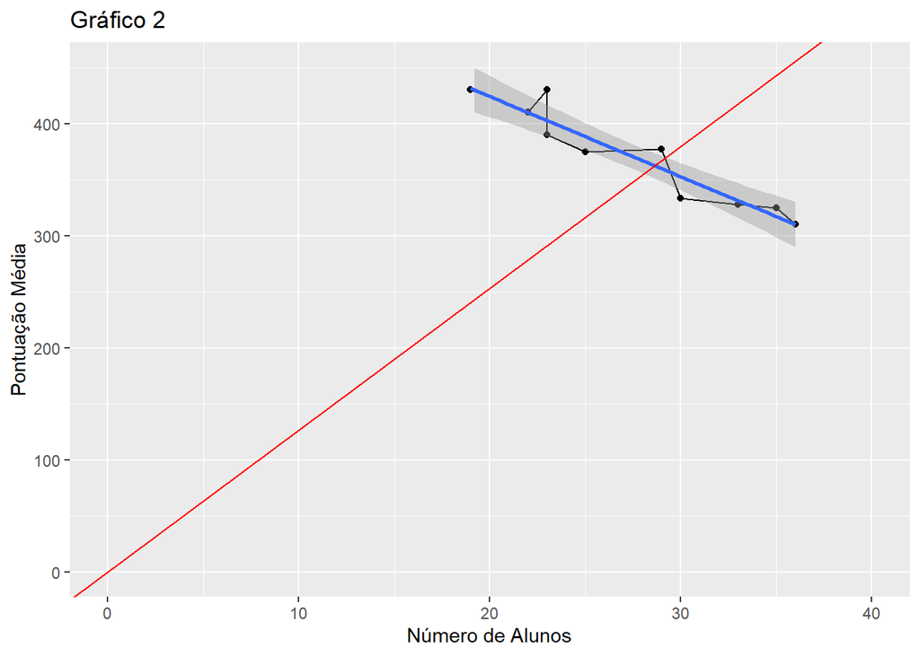

```r
est_coef_estimados2 <- summary(reg_sem_intercepto)

coef_estimados2 <- tibble("Coeficientes" = "Var. Explicativa",
                         "Valor do Coef" = est_coef_estimados2$coefficients[1],
                         "R-quadrado" = est_coef_estimados2$r.squared,
                         "Erro-padrão" = est_coef_estimados2$coefficients[2],
                         "Estatística-t" = est_coef_estimados2$coefficients[3],
                         "P-Valor" = est_coef_estimados2$coefficients[4]
                         )

grafico_2 <- ggplot(df, aes(x = Num_de_Alunos , y = Pont_Media)) +
        geom_point() +
        ggtitle("Gráfico 2") +
        geom_line() +
        xlab("Número de Alunos") +
        ylab("Pontuação Média") +
        xlim(0, 40) +
        ylim(0, 450) +
        geom_smooth(method = "lm") +
        geom_abline(slope = est_coef_estimados2$coefficients[1] , intercept = 0, color = "red")

print(grafico_2)
```

#### QUESTÃO 13:

A inclusão de um intercepto na origem do modelo propõe maior abrangência na análise dos dados. O ponto (0,0) representa a nota média de uma turma que contém zero alunos, ou seja, deve ser zero para que a interpretação do intercepto faça sentido. Dessa forma, é possível estimar o relacionamento entre as variáveis que estão fora do intervalo amostral.

Estatisticamente, podemos demonstrar que o modelo sem intercepto possui R-quadrado ligeiramente maior em relação ao modelo inicial (o que representa que a sua ESS (Expected Sum of Squares) é proporcionalmente maior em relação à sua TSS (Total Sum of Squares). Além disso, pode-se observar que o erro-padrão da variável explicativa no modelo sem intercepto é maior do que o erro-padrão da variável explicativa no modelo inicial, o que representa uma perda proporcionalmente significativa na capacidade preditiva do modelo sem intercepto.

Pode-se observar claro enviesamento do modelo sem intercepto ao realizar uma avaliação visual da regressão. Isso demonstra que ainda que seja lógico, não é viável utilizar uma análise puramente centrada no valor do intercepto como forma de definir a validade da regressão, pois o viés de interpretação pode se alterar completamente, ao ponto de não se explicar de maneira correta o relacionamento entre as variáveis de interesse obtidas na amostra.

O enviesamento é explicado pelo coeficiente de correlação entre as variáveis amostrais, que por ser próximo de -1 (no modelo inicial), representa uma dependência linear inversamente proporcional entre a quantidade de alunos da turma e a sua pontuação média. O modelo sem intercepto apresenta uma regressão de inclinação positiva e um coeficiente de correlação maior do que zero, o que propõe uma possível dependência linear proporcional entre as variáveis, o que não condiz com os resultados obtidos na amostra.

```r
print(coef_estimados)
```

```
## # A tibble: 2 x 6
##   Coeficientes `Valor dos Coef` `R-quadrado` `Erro-padrão` `Estatística-t`
##   <chr>                   <dbl>        <dbl>         <dbl>           <dbl>
## 1 Intercepto             567.          0.898        24.0             23.7
## 2 Var.Explica~            -7.15        0.898         0.854           -8.38
## # ... with 1 more variable: `P-Valor` <dbl>
```

```r
print(coef_estimados2)
```

```
## # A tibble: 1 x 6
##   Coeficientes `Valor do Coef` `R-quadrado` `Erro-padrão` `Estatística-t`
##   <chr>                  <dbl>        <dbl>         <dbl>           <dbl>
## 1 Var. Explic~            12.7        0.906          1.36            9.30
## # ... with 1 more variable: `P-Valor` <dbl>
```

```r
print(paste("O P-valor da regressão sem intercepto é", est_coef_estimados2$coefficients[4]))
```

```
## [1] "O P-valor da regressão sem intercepto é 6.50055982248613e-06"
```

```r
corr <- cor(df$Num_de_Alunos, df$Pont_Media)
print(paste("A correlação entre o número de alunos por turma e sua pontuação média é de", corr))
```

```
## [1] "A correlação entre o número de alunos por turma e sua pontuação média é de -0.947442434033449"
```